# SSVEP reward - EEG results

```r
paste("Mean = ",round(mean(Diff_Bsln_Acq_High_vs_Low), digits = 2), " [", round(hdi(Diff_Bsln_Acq_High_vs_Low)[[1]], digits = 2), " ", round(hdi(Diff_Bsln_Acq_High_vs_Low)[[2]], digits = 2), "]")
```

```
## [1] "Mean =  -8.49  [ -18.61   2.06 ]"
```

```r
length(Diff_Bsln_Acq_High_vs_Low)
```

```
## [1] 12000
```

Check the difference between high reward in acquisition vs. extinction

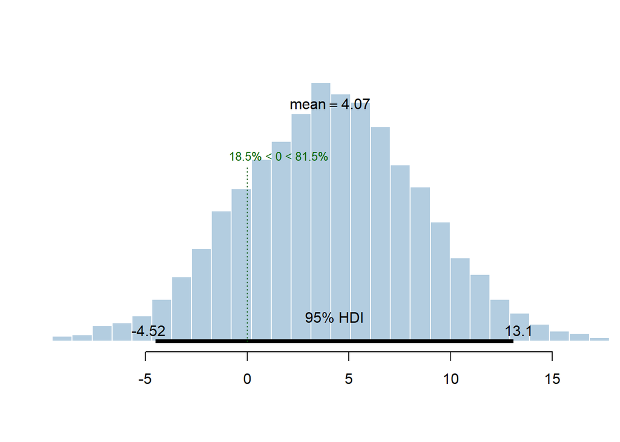

```r
Diff_Acq_Ext_High = Extinction_High - Acquisition_High
plotPost(Diff_Acq_Ext_High, xlab = "", col = "#b3cde0", showCurve = FALSE, cex = 1, compVal = 0)
```

```r
length(Diff_Acq_Ext_High)
```

```
## [1] 12000
```

Check the difference between low reward in acquisition vs. extinction

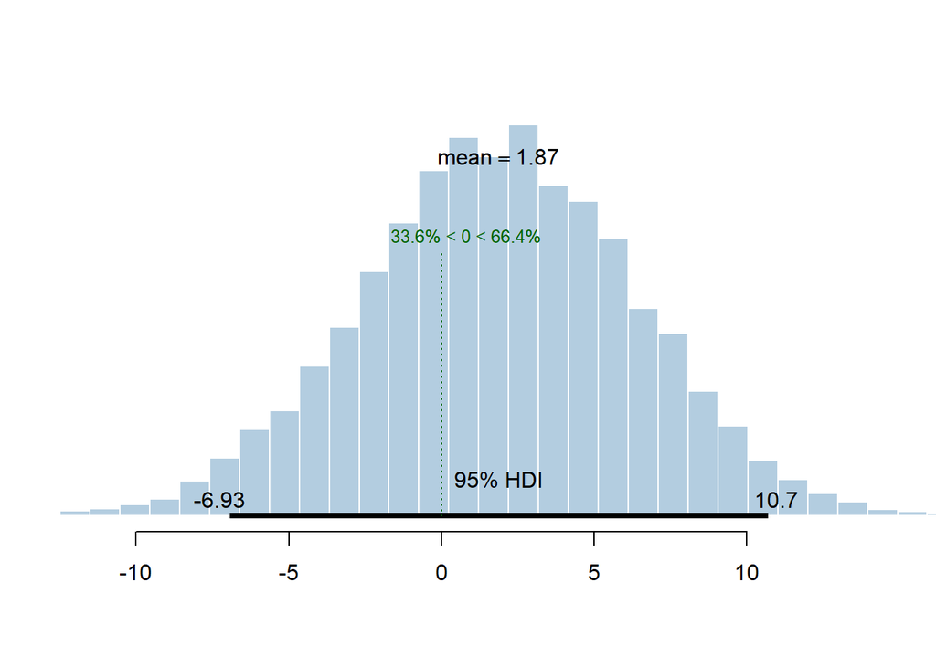

```r
Diff_Acq_Ext_Low = Extinction_Low - Acquisition_Low
plotPost(Diff_Acq_Ext_Low, xlab = "", col = "#b3cde0", showCurve = FALSE, cex = 1, compVal = 0)
```

```r
length(Diff_Acq_Ext_Low)
```

```
## [1] 12000
```

# Behavior - splitting the phases

## Import data

```r
# Clear environemnt and import data------------------------------------------------------------------------------------------------------------------------------------------------------------------------------------------------------

# # clear the environment
# rm(list=ls())
# # clear the console
# cat("\014")
# #load packages and install them if they're not installed
# if (!require("pacman")) install.packages("pacman")
# pacman::p_load(plyr,Rmisc,yarrr,BayesFactor,reshape2,brms, broom, tidyverse, brmstools, BEST, knitr, here,psych)
# # set seed
# set.seed(42)
# # set directory
# setwd(here())
# import data
data.raw = read.csv(file = here("data","Data_behavior_exp1_48pps.csv"),header=TRUE,na.strings="NaN")

# Prepare the dataset------------------------------------------------------------------------------------------------------------------------------------------------------------------------------------------------------

### Adding and renaming variables
# rename EventType variable
names(data.raw)[names(data.raw) == "EventType"] = "MovedDots"
# add a variable with the name of the attended color instead of a numbers
data.raw$AttendedColor = ifelse(data.raw$AttendedColor==1,"red","blue")
# add a variable saying which color was linked with High_Rew (even numbers - blue was High_Rew)
data.raw$RewardedColor = ifelse(data.raw$ParticipantNo%%2==0,"blue","red")
# add a variable with the name of the moved color instead of a numbers
data.raw$MovedDots = ifelse(data.raw$MovedDots==1,"red","blue")
# split experimental phases into 6 isntead of 3 phases (trial 0-200: Bsln; trial 201-400: Acq; trial 401-600: Ext)
data.raw$ExpPhase = cut(data.raw$Trial,breaks=c(0,100,200,300,400,500,600),labels=c("Bsln1","Bsln2","Acq1","Acq2","Ext1","Ext2"))
# split experimental phases into 3 phases (trial 0-200: Bsln; trial 201-400: Acq; trial 401-600: Ext)
# data.raw$ExpPhase = cut(data.raw$Trial,breaks=c(0,200,400,600),labels=c("Bsln","Acq","Ext")) # trial 0-200: Bsln; trial 201-400: Acq; trial 401-600: Ext

### Convert variables to be used in analyses into factors
data.raw[c("ParticipantNo", "AttendedColor","RewardedColor", "MovedDots", "ExpPhase" )] =
  lapply(data.raw[c("ParticipantNo", "AttendedColor","RewardedColor", "MovedDots", "ExpPhase" )], factor)

### Create variables needed for the accuracy analyses
# count hits, false alarms, misses, correct rejections, and RT separately for each participant (their calculation is done in Matlab: see DataProcessing.m)
data.final = ddply(data.raw,.(ParticipantNo,ExpPhase,AttendedColor,RewardedColor,MovedDots),summarize,
                  numtrials=length(which(Response!=99)), # number of trials per condition (anything that is not 99 or any other number that we're not using)
                  Hits=length(which(Response==1)), # hits: attended color moved, correct response
                  FAs=length(which(Response==2)), # false alarms: attended color did not move, (wrong) response
                  Misses=length(which(Response==0)), # misses: attended color moved, no response
                  CRs=length(which(Response==3)), # correct rejections: attended color did not move, no response
                  mean.RT=mean(RT,na.rm=TRUE)) # mean RT per condition


################################################################## Calculate accuracy and RTs per condition ###############################################################################################################################################################################################################

# Prepare the data------------------------------------------------------------------------------------------------------------------------------------------------------------------------------------------------------

### Calculate Hits and False alarms
# Hits are calculated for each participant in each condition on trials when they are attending the color that moved.
# False alarms are  calculated for each participant in each condition on trials when they are attending the color that didn't move (the unattended color moved, but they responded)
# Here we create the same number of hits & fas for each of the two conditions (moved attended or not)
data.final = ddply(data.final, .(ParticipantNo,ExpPhase,AttendedColor), transform,
                 Hits = Hits[MovedDots==AttendedColor],
                 FAs = FAs[MovedDots!=AttendedColor])

# Keep only trials on which the attended color moved (we can do behavioral analysis only on those)
data.final = subset(data.final,MovedDots==AttendedColor)

### Calculate d'
# use loglinear transformation: add 0.5 to Hits, FAs, Misses, and CRs (Hautus, 1995, Behavior Research Methods, Instruments, & Computers),
# which is preferred over the 1/2N rule (Macmillan & Kaplan, 1985, Psychological Bulletin) because it results in less biased estimates of d'.
data.final =  ddply(data.final,.(ParticipantNo,ExpPhase,RewardedColor,AttendedColor,numtrials),summarise,
                    tot.Hits=Hits+.5, # hits
                    tot.FAs=FAs+.5, # false alarms
                    tot.Misses=(numtrials-Hits)+.5, # misses
                    tot.CRs=(numtrials-FAs)+.5, # correct rejections
                    Hit.Rate=tot.Hits/(tot.Hits+tot.Misses), # hit rate
                    FA.Rate=tot.FAs/(tot.FAs+tot.CRs), # false alarm rate
                    #dprime=qnorm(Hit.Rate)-qnorm(FA.Rate),
                    Hits.RTs=mean(mean.RT,na.rm=TRUE)) # mean RTs

# Calculate SDT indices with psycho
indices = psycho::dprime(data.final$tot.Hits, data.final$tot.FAs, data.final$tot.Misses, data.final$tot.CRs)

data.final = cbind(data.final, indices)


### Create a final dataframe for accuracy and RTs analyses
# add a new variable specifying whether the participant is attending the high or Low_Rewed color
data.final$Condition = ifelse(data.final$RewardedColor==data.final$AttendedColor,"High_Rew","Low_Rew")
# make this variable a factor for further analyses
data.final$Condition = factor(data.final$Condition)

# Exclude subjects without EEG
missing_eeg = c(5,10,13,27,14)
data.final = data.final[!data.final$ParticipantNo %in% missing_eeg,]
```

## D prime

### Means - D prime - raw data

```r
summary = ddply(data.final,.(ExpPhase,Condition),plyr::summarize,Mean=c(paste(round(mean(dprime, na.rm = TRUE), digits = 2), " [", round(hdi(dprime)[[1]], digits = 2), " ", round(hdi(dprime)[[2]], digits = 2), "]")))

names(summary) = c("Reward phase", "Reward probability", "Dprime")

# rename conditions
summary$`Reward phase` = recode(summary$`Reward phase`,
                                "Acq1" = "Acquisition1",
                                "Acq2" = "Acquisition2",
                                "Bsln1" = "Baseline1",
                                "Bsln2" = "Baseline2",
                                "Ext1" = "Extinction1",
                                "Ext2" = "Extinction2")

summary$`Reward probability` = recode(summary$`Reward probability`,
                           "High_Rew" = "High",
                           "Low_Rew" = "Low")

summary = as.data.frame(summary)

kable(summary, caption = "Dprime per condition")
```

Dprime per condition

| Reward phase | Reward probability | Dprime |
| --- | --- | --- |
| Baseline1 | High | 1.48 [ -0.36 2.62 ] |
| Baseline1 | Low | 1.32 [ 0.09 2.35 ] |
| Baseline2 | High | 1.6 [ -0.27 2.56 ] |
| Baseline2 | Low | 1.47 [ 0.08 2.33 ] |
| Acquisition1 | High | 1.54 [ -0.08 2.65 ] |
| Acquisition1 | Low | 1.59 [ 0.47 2.45 ] |
| Acquisition2 | High | 1.59 [ 0.08 2.56 ] |
| Acquisition2 | Low | 1.48 [ 0 2.62 ] |
| Extinction1 | High | 1.48 [ -0.07 2.47 ] |
| Extinction1 | Low | 1.5 [ 0.36 2.5 ] |
| Extinction2 | High | 1.49 [ -0.38 2.49 ] |
| Extinction2 | Low | 1.55 [ 0.65 2.55 ] |

### Plot

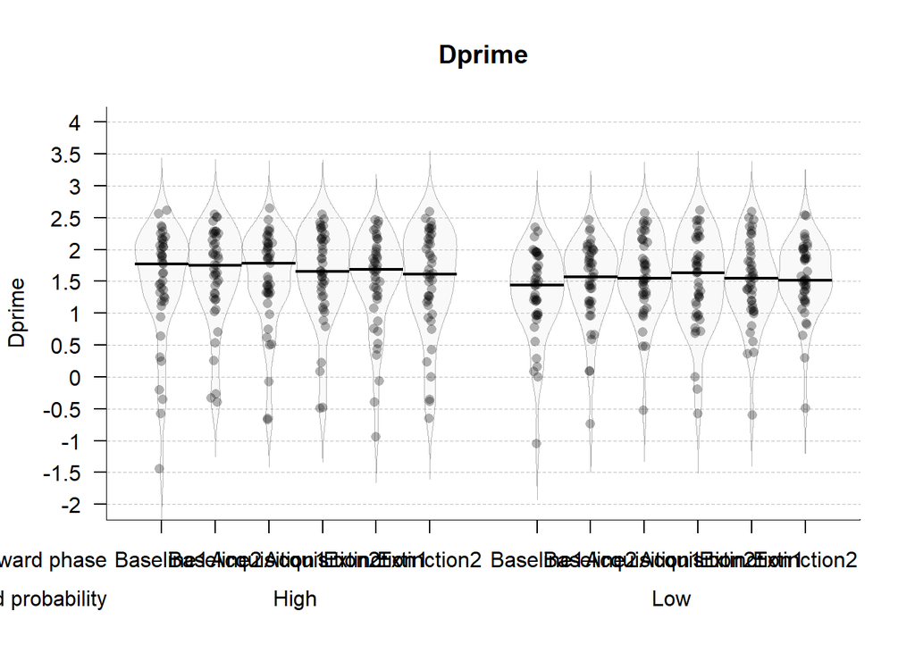

```r
# # Plot FA rates------------------------------------------------------------------------------------------------------------------------------------------------------------------------------------------------------
# Prepare the dataset
data.plot = data.final

# rename variables
colnames(data.plot)[colnames(data.plot)=="ExpPhase"] <- "Reward phase"
colnames(data.plot)[colnames(data.plot)=="Condition"] <- "Reward probability"

# rename conditions
data.plot$`Reward phase` = recode(data.plot$`Reward phase`,
                                "Acq1" = "Acquisition1",
                                "Acq2" = "Acquisition2",
                                "Bsln1" = "Baseline1",
                                "Bsln2" = "Baseline2",
                                "Ext1" = "Extinction1",
                                "Ext2" = "Extinction2")

data.plot$`Reward probability` = recode(data.plot$`Reward probability`,
                                      "High_Rew" = "High",
                                      "Low_Rew" = "Low")
  # Pirate plot
  pirateplot(formula=dprime ~ `Reward phase` + `Reward probability`, # dependent~independent variables
             data=data.plot, # data frame
             main="Dprime", # main title
             ylim=c(-2,4), # y-axis: limits
             ylab="Dprime", # y-axis: label
             theme=0, # preset theme (0: use your own)
             point.col="black", # points: color
             point.o=.3, # points: opacity (0-1)
             avg.line.fun = median,
             avg.line.col="black", # average line: color
             avg.line.lwd=2, # average line: line width
             avg.line.o=1, # average line: opacity (0-1)
             bean.b.col="black", # bean border, color
             bean.lwd=0.6, # bean border, line width
             bean.lty=1, # bean border, line type (1: solid; 2:dashed; 3: dotted; ...)
             bean.b.o=0.3, # bean border, opacity (0-1)
             bean.f.col="gray", # bean filling, color
             bean.f.o=.1, # bean filling, opacity (0-1)
             cap.beans=FALSE, # max and min values of bean densities are capped at the limits found in the data
             gl.col="gray", # gridlines: color
             gl.lty=2, # gridlines: line type (1: solid; 2:dashed; 3: dotted; ...)
             cex.lab=1, # axis labels: size
             cex.axis=1, # axis numbers: size
             cex.names = 1,
             bty="l", # plot box type
             back.col="white") # background, color
```

### Statistics

```r
# Set the working directory in order to load the models
# Set working directory
setwd(here("brms_models"))


model.full.Acc.dprime.split = readRDS("model.full.Acc.dprime.split.rds")
compare.waic.Acc.dprime.split = readRDS("compare.Acc.dprime.split.waic")
compare.Acc.dprime.split.waic.weights = readRDS("compare.Acc.dprime.split.waic.weights")
bR2.null.Acc.dprime.split = readRDS("bR2.null.Acc.dprime.split")
bR2.expphase.Acc.dprime.split = readRDS("bR2.expphase.Acc.dprime.split")
bR2.full.Acc.dprime.split = readRDS("bR2.full.Acc.dprime.split")
```

### Model comparison with WAIC

```r
print(compare.waic.Acc.dprime.split)
```

```
## Output of model 'model.null.Acc.dprime':
##
## Computed from 12000 by 516 log-likelihood matrix
##
##           Estimate   SE
## elpd_waic   -500.8 17.7
## p_waic        36.2  2.5
## waic        1001.5 35.4
##
## Output of model 'model.expphase.Acc.dprime':
##
## Computed from 12000 by 516 log-likelihood matrix
##
##           Estimate   SE
## elpd_waic   -509.5 17.7
## p_waic        48.1  3.2
## waic        1019.1 35.3
##
## Output of model 'model.full.Acc.dprime':
##
## Computed from 12000 by 516 log-likelihood matrix
##
##           Estimate   SE
## elpd_waic   -275.4 17.0
## p_waic       102.8  6.3
## waic         550.8 34.1
##
## Model comparisons:
##                           elpd_diff se_diff
## model.full.Acc.dprime        0.0       0.0
## model.null.Acc.dprime     -225.4      19.9
## model.expphase.Acc.dprime -234.1      19.9
```

### Bayesian R squared

Null model

```r
print(bR2.null.Acc.dprime.split)
```

```
##     Estimate  Est.Error      Q2.5     Q97.5
## R2 0.2864918 0.03099612 0.2239089 0.3449991
```

Experiment phase model

```r
print(bR2.expphase.Acc.dprime.split)
```

```
##     Estimate  Est.Error      Q2.5     Q97.5
## R2 0.3007569 0.03047797 0.2382382 0.3576129
```

Full model

```r
print(bR2.full.Acc.dprime.split)
```

```
##     Estimate  Est.Error      Q2.5    Q97.5
## R2 0.7493958 0.01352598 0.7212571 0.774454
```

### Checking the best model

Plotting the chains

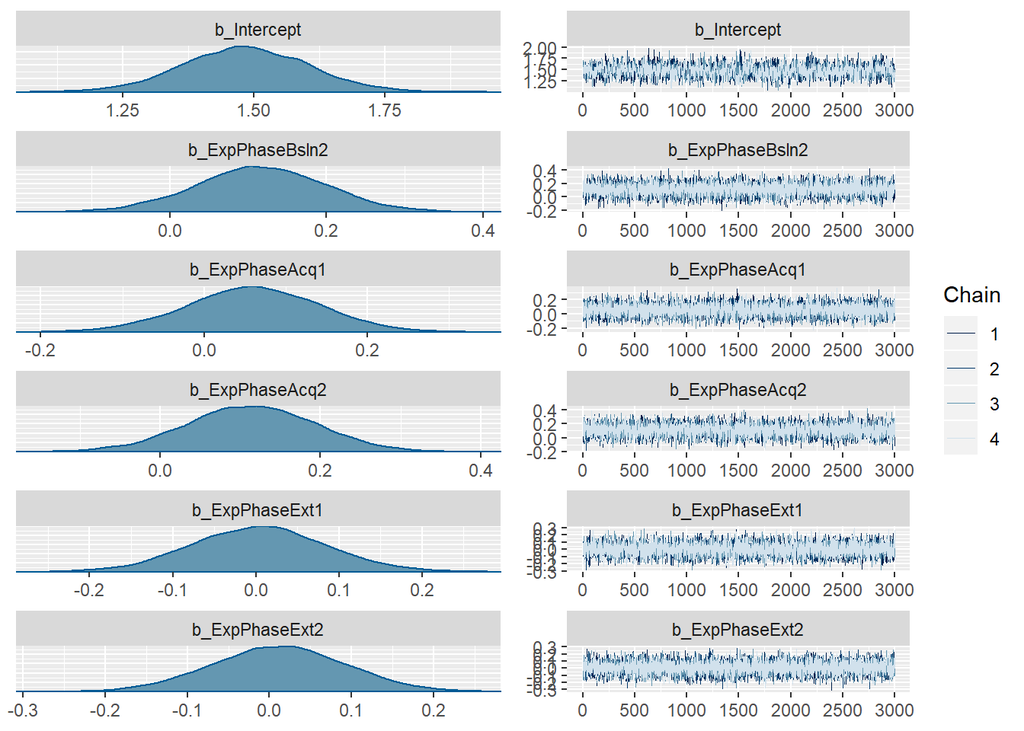

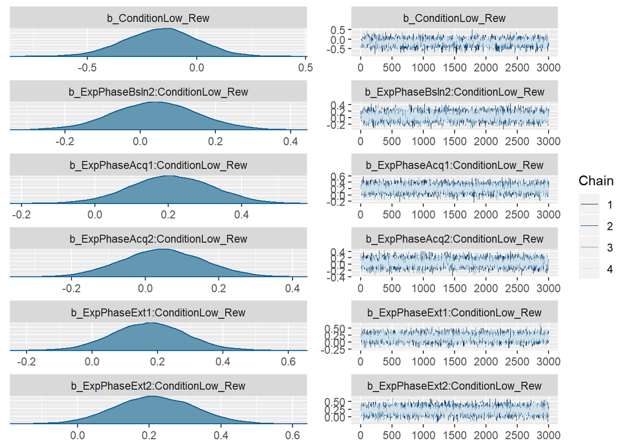

```r
# Plot chains
plot(model.full.Acc.dprime.split, pars = "^b_", ask = FALSE, N=6)
```

Summary of the best model

```r
# Summary of the best model
print(tidy(model.full.Acc.dprime.split, par_type = "non-varying"), digits = 1)
```

```
##                              term estimate std.error  lower upper
## 1                       Intercept    1.484      0.12  1.289   1.7
## 2                   ExpPhaseBsln2    0.116      0.08 -0.023   0.3
## 3                    ExpPhaseAcq1    0.060      0.08 -0.074   0.2
## 4                    ExpPhaseAcq2    0.113      0.08 -0.019   0.2
## 5                    ExpPhaseExt1    0.004      0.08 -0.128   0.1
## 6                    ExpPhaseExt2    0.011      0.08 -0.124   0.1
## 7                ConditionLow_Rew   -0.164      0.17 -0.439   0.1
## 8  ExpPhaseBsln2:ConditionLow_Rew    0.040      0.11 -0.145   0.2
## 9   ExpPhaseAcq1:ConditionLow_Rew    0.208      0.11  0.024   0.4
## 10  ExpPhaseAcq2:ConditionLow_Rew    0.048      0.11 -0.136   0.2
## 11  ExpPhaseExt1:ConditionLow_Rew    0.175      0.11 -0.009   0.4
## 12  ExpPhaseExt2:ConditionLow_Rew    0.215      0.11  0.033   0.4
```

### Plotting the best model

#### Sample from the posterior

```r
# Analyzing the posterior and differences between conditions

post = posterior_samples(model.full.Acc.dprime.split, "^b")


################################################ Baseline 1 ####

######### High reward
Baseline1_High = post[["b_Intercept"]]
######### Low reward
Baseline1_Low = post[["b_Intercept"]] +
  post[["b_ConditionLow_Rew"]]

################################################ Baseline 2 ####

######### High reward
Baseline2_High = post[["b_Intercept"]] +
  post[["b_ExpPhaseBsln2"]]
######### Low reward
Baseline2_Low = post[["b_Intercept"]] +
  post[["b_ExpPhaseBsln2"]] +
  post[["b_ConditionLow_Rew"]] +
  post[["b_ExpPhaseBsln2:ConditionLow_Rew"]]

################################################ Acquistion 1

######### High reward
Acquisition1_High = post[["b_Intercept"]] +
  post[["b_ExpPhaseAcq1"]]
######### Low reward
Acquisition1_Low = post[["b_Intercept"]] +
  post[["b_ExpPhaseAcq1"]] +
  post[["b_ConditionLow_Rew"]] +
  post[["b_ExpPhaseAcq1:ConditionLow_Rew"]]

################################################ Acquistion 2

######### High reward
Acquisition2_High = post[["b_Intercept"]] +
  post[["b_ExpPhaseAcq2"]]
######### Low reward
Acquisition2_Low = post[["b_Intercept"]] +
  post[["b_ExpPhaseAcq2"]] +
  post[["b_ConditionLow_Rew"]] +
  post[["b_ExpPhaseAcq2:ConditionLow_Rew"]]

################################################ Extinction 1

######### High reward
Extinction1_High = post[["b_Intercept"]] +
  post[["b_ExpPhaseExt1"]]
######### Low reward
Extinction1_Low = post[["b_Intercept"]] +
  post[["b_ExpPhaseExt1"]] +
  post[["b_ConditionLow_Rew"]] +
  post[["b_ExpPhaseExt1:ConditionLow_Rew"]]

################################################ Extinction 2

######### High reward
Extinction2_High = post[["b_Intercept"]] +
  post[["b_ExpPhaseExt2"]]
######### Low reward
Extinction2_Low = post[["b_Intercept"]] +
  post[["b_ExpPhaseExt2"]] +
  post[["b_ConditionLow_Rew"]] +
  post[["b_ExpPhaseExt2:ConditionLow_Rew"]]
```

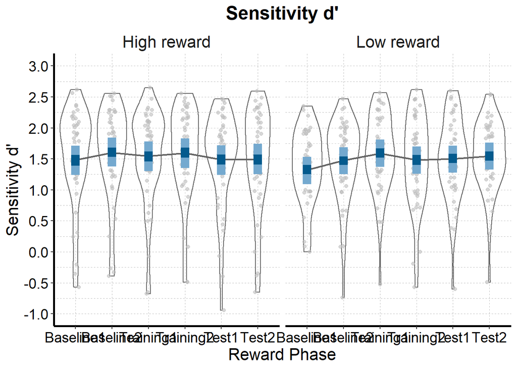

```r
# Data from the model

# make a data frame
posterior_conditions = melt(data.frame(Baseline1_High, Baseline2_High, Baseline1_Low, Baseline2_Low, Acquisition1_High, Acquisition1_Low, Acquisition2_High, Acquisition2_Low, Extinction1_High, Extinction1_Low, Extinction2_High, Extinction2_Low))

posterior_conditions =  posterior_conditions %>% separate(variable, c("Reward Phase", "Reward Probability"), "_", extra = "merge")

names(posterior_conditions)[3] = "dprime"

posterior_conditions$`Reward Probability` = recode(posterior_conditions$`Reward Probability`,
                                      "High" = "High reward",
                                      "Low" = "Low reward")

posterior_conditions$`Reward Phase` = recode(posterior_conditions$`Reward Phase`,
                                "Acquisition1" = "Training1",
                                "Acquisition2" = "Training2",
                                "Baseline1" = "Baseline1",
                                "Baseline1" = "Baseline2",
                                "Extinction1" = "Test1",
                                "Extinction2" = "Test2")

# Make a table with credible intervals
posterior_means = as.data.frame(c("Baseline1 High Reward",
                                  "Baseline2 High Reward",
                                  "Baseline1 Low Reward",
                                  "Baseline2 Low Reward",
                                  "Acquisition1 High Reward",
                                  "Acquisition2 High Reward",
                                  "Acquisition1 Low Reward",
                                  "Acquisition2 Low Reward",
                                  "Extinction1 High Reward",
                                  "Extinction2 High Reward",
                                  "Extinction1 Low Reward",
                                  "Extinction2 Low Reward"))
names(posterior_means)[1] = "Condition"

posterior_means$low_95_CI = c(round(hdi(Baseline1_High)[[1]], digits = 2),
                              round(hdi(Baseline2_High)[[1]], digits = 2),
                        round(hdi(Baseline1_Low)[[1]], digits = 2),
                        round(hdi(Baseline2_Low)[[1]], digits = 2),
                        round(hdi(Acquisition1_High)[[1]], digits = 2),
                        round(hdi(Acquisition2_High)[[1]], digits = 2),
                        round(hdi(Acquisition1_Low)[[1]], digits = 2),
                        round(hdi(Acquisition2_Low)[[1]], digits = 2),
                        round(hdi(Extinction1_High)[[1]], digits = 2),
                        round(hdi(Extinction2_High)[[1]], digits = 2),
                        round(hdi(Extinction1_Low)[[1]], digits = 2),
                        round(hdi(Extinction2_Low)[[1]], digits = 2))

posterior_means$high_95_CI = c(round(hdi(Baseline1_High)[[2]], digits = 2),
                              round(hdi(Baseline2_High)[[2]], digits = 2),
                        round(hdi(Baseline1_Low)[[2]], digits = 2),
                        round(hdi(Baseline2_Low)[[2]], digits = 2),
                        round(hdi(Acquisition1_High)[[2]], digits = 2),
                        round(hdi(Acquisition2_High)[[2]], digits = 2),
                        round(hdi(Acquisition1_Low)[[2]], digits = 2),
                        round(hdi(Acquisition2_Low)[[2]], digits = 2),
                        round(hdi(Extinction1_High)[[2]], digits = 2),
                        round(hdi(Extinction2_High)[[2]], digits = 2),
                        round(hdi(Extinction1_Low)[[2]], digits = 2),
                        round(hdi(Extinction2_Low)[[2]], digits = 2))

posterior_means$low_50_CI = c(round(hdi(Baseline1_High,0.5)[[1]], digits = 2),
                              round(hdi(Baseline2_High,0.5)[[1]], digits = 2),
                        round(hdi(Baseline1_Low,0.5)[[1]], digits = 2),
                        round(hdi(Baseline2_Low,0.5)[[1]], digits = 2),
                        round(hdi(Acquisition1_High,0.5)[[1]], digits = 2),
                        round(hdi(Acquisition2_High,0.5)[[1]], digits = 2),
                        round(hdi(Acquisition1_Low,0.5)[[1]], digits = 2),
                        round(hdi(Acquisition2_Low,0.5)[[1]], digits = 2),
                        round(hdi(Extinction1_High,0.5)[[1]], digits = 2),
                        round(hdi(Extinction2_High,0.5)[[1]], digits = 2),
                        round(hdi(Extinction1_Low,0.5)[[1]], digits = 2),
                        round(hdi(Extinction2_Low,0.5)[[1]], digits = 2))

posterior_means$high_50_CI = c(round(hdi(Baseline1_High,0.5)[[2]], digits = 2),
                              round(hdi(Baseline2_High,0.5)[[2]], digits = 2),
                        round(hdi(Baseline1_Low,0.5)[[2]], digits = 2),
                        round(hdi(Baseline2_Low,0.5)[[2]], digits = 2),
                        round(hdi(Acquisition1_High,0.5)[[2]], digits = 2),
                        round(hdi(Acquisition2_High,0.5)[[2]], digits = 2),
                        round(hdi(Acquisition1_Low,0.5)[[2]], digits = 2),
                        round(hdi(Acquisition2_Low,0.5)[[2]], digits = 2),
                        round(hdi(Extinction1_High,0.5)[[2]], digits = 2),
                        round(hdi(Extinction2_High,0.5)[[2]], digits = 2),
                        round(hdi(Extinction1_Low,0.5)[[2]], digits = 2),
                        round(hdi(Extinction2_Low,0.5)[[2]], digits = 2))


posterior_means =  posterior_means %>% separate(Condition, c("Reward Phase", "Reward Probability"), " ", extra = "merge")

posterior_means$`Reward Probability` = recode(posterior_means$`Reward Probability`,
                                      "High Reward" = "High reward",
                                      "Low Reward" = "Low reward")

posterior_means$`Reward Phase` = recode(posterior_means$`Reward Phase`,
                                "Acquisition1" = "Training1",
                                "Acquisition2" = "Training2",
                                "Baseline1" = "Baseline1",
                                "Baseline1" = "Baseline2",
                                "Extinction1" = "Test1",
                                "Extinction2" = "Test2")

# Create this variable in order to have it for plotting (this is a quick hack: in plotting the CIs this variable is added and then subtracted)
posterior_means$`dprime` = c(1,1,1,1,1,1)


# Raw data
# Prepare the dataset
data.plot = data.final

# rename variables
colnames(data.plot)[colnames(data.plot)=="ExpPhase"] = "Reward Phase"
colnames(data.plot)[colnames(data.plot)=="Condition"] = "Reward Probability"

# rename conditions
data.plot$`Reward Phase` = recode(data.plot$`Reward Phase`,
                                "Acq1" = "Training1",
                                "Acq2" = "Training2",
                                "Bsln1" = "Baseline1",
                                "Bsln2" = "Baseline2",
                                "Ext1" = "Test1",
                                "Ext2" = "Test2")

data.plot$`Reward Probability` = recode(data.plot$`Reward Probability`,
                                      "High_Rew" = "High reward",
                                      "Low_Rew" = "Low reward")


# Violin + the model
# tiff("dprime_split.tiff", units="in", width=16, height=5, res=800)

f.sup.a = ggplot(data=data.plot, aes(x=`Reward Phase`, y=`dprime`, label=`Reward Probability`)) +
  # violin of the raw data
  geom_violin(data=data.plot, color ="#636363",trim = TRUE,alpha="0.2") +
  # individual participants for the raw data
  # geom_point(binaxis='y', stackdir='center', dotsize=0.5, alpha="0.2") +
  geom_jitter(dotsize=0.9, alpha="0.6",width = 0.1,color="#bdbdbd")+
  # mean of the model
  stat_summary(data = posterior_conditions, aes(x=`Reward Phase`, y=`dprime`, group=`Reward Probability`),fun.y = mean, geom="line",size=0.8, colour = "#636363")+
  # 95 credible intervals of the model
  geom_linerange(data = posterior_means,width=.1, aes(ymin=`dprime`-`dprime`+low_95_CI, ymax=`dprime`-`dprime`+high_95_CI), size = 4, color = "#74a9cf", alpha = 1) +
  # 50 credible intervals of the model
  geom_linerange(data = posterior_means,width=.1, aes(ymin=`dprime`-`dprime`+low_50_CI, ymax=`dprime`-`dprime`+high_50_CI), size = 4, color = "#045a8d", alpha = 1) +
  scale_x_discrete(limits=c("Baseline1","Baseline2", "Training1","Training2", "Test1","Test2")) +
  facet_grid(.~`Reward Probability`) +
  scale_y_continuous(limits = c(-1,3),breaks=seq(-1,3,0.5)) +
  labs(title="Sensitivity d′", y = "Sensitivity d′") +
  theme(
    axis.line = element_line(size=1, colour = "black"),
    panel.grid.major = element_line(colour = "grey",size = 0.1,linetype = "dashed"),
    panel.grid.minor = element_line(colour = "grey",size = 0.1,linetype = "dashed"),
    panel.border = element_blank(),
    panel.background = element_blank(),
    plot.title = element_text(size = 18,  face = "bold",hjust = 0.5),
    text=element_text(colour="black", size = 14),
    axis.text.x=element_text(colour="black", size = 14),
    axis.text.y=element_text(colour="black", size = 14),
    axis.title=element_text(size=16,colour = "black")) +
  theme(strip.background =element_rect(fill="white")) +
  theme(strip.text = element_text(size = 16))

f.sup.a
```

```r
# dev.off()
```

Table of means across conditions

```r
# Make a table with conditions
posterior_means = as.data.frame(c("Baseline1 High Reward",
                                  "Baseline1 Low Reward",
                                  "Baseline2 High Reward",
                                  "Baseline2 Low Reward",
                                  "Acquisition1 High Reward",
                                  "Acquisition1 Low Reward",
                                  "Acquisition2 High Reward",
                                  "Acquisition2 Low Reward",
                                  "Extinction1 High Reward",
                                  "Extinction1 Low Reward",
                                  "Extinction2 High Reward",
                                  "Extinction2 Low Reward"))

names(posterior_means)[1] = "Condition"

posterior_means$Mean = c(paste(round(mean(Baseline1_High), digits = 2), " [", round(hdi(Baseline1_High)[[1]], digits = 2), " ", round(hdi(Baseline1_High)[[2]], digits = 2), "]"),
                         paste(round(mean(Baseline1_Low), digits = 2), " [", round(hdi(Baseline1_Low)[[1]], digits = 2), " ", round(hdi(Baseline1_Low)[[2]], digits = 2), "]"),
                         paste(round(mean(Baseline2_High), digits = 2), " [", round(hdi(Baseline2_High)[[1]], digits = 2), " ", round(hdi(Baseline2_High)[[2]], digits = 2), "]"),
                         paste(round(mean(Baseline2_Low), digits = 2), " [", round(hdi(Baseline2_Low)[[1]], digits = 2), " ", round(hdi(Baseline2_Low)[[2]], digits = 2), "]"),
                         paste(round(mean(Acquisition1_High), digits = 2), " [", round(hdi(Acquisition1_High)[[1]], digits = 2), " ", round(hdi(Acquisition1_High)[[2]], digits = 2), "]"),
                         paste(round(mean(Acquisition1_Low), digits = 2), " [", round(hdi(Acquisition1_Low)[[1]], digits = 2), " ", round(hdi(Acquisition1_Low)[[2]], digits = 2), "]"),
                         paste(round(mean(Acquisition2_High), digits = 2), " [", round(hdi(Acquisition2_High)[[1]], digits = 2), " ", round(hdi(Acquisition2_High)[[2]], digits = 2), "]"),
                         paste(round(mean(Acquisition2_Low), digits = 2), " [", round(hdi(Acquisition2_Low)[[1]], digits = 2), " ", round(hdi(Acquisition2_Low)[[2]], digits = 2), "]"),
                         paste(round(mean(Extinction1_High), digits = 2), " [", round(hdi(Extinction1_High)[[1]], digits = 2), " ", round(hdi(Extinction1_High)[[2]], digits = 2), "]"),
                         paste(round(mean(Extinction1_Low), digits = 2), " [", round(hdi(Extinction1_Low)[[1]], digits = 2), " ", round(hdi(Extinction1_Low)[[2]], digits = 2), "]"),
                         paste(round(mean(Extinction2_High), digits = 2), " [", round(hdi(Extinction2_High)[[1]], digits = 2), " ", round(hdi(Extinction2_High)[[2]], digits = 2), "]"),
                         paste(round(mean(Extinction2_Low), digits = 2), " [", round(hdi(Extinction2_Low)[[1]], digits = 2), " ", round(hdi(Extinction2_Low)[[2]], digits = 2), "]"))

names(posterior_means)[2] = "Mean [HDI]"

posterior_means =  posterior_means %>% separate(Condition, c("Reward Phase", "Reward Probability"), " ", extra = "merge")

kable(posterior_means, caption = "Means per condition")
```

Means per condition

| Reward Phase | Reward Probability | Mean [HDI] |
| --- | --- | --- |
| Baseline1 | High Reward | 1.48 [ 1.24 1.71 ] |
| Baseline1 | Low Reward | 1.32 [ 1.09 1.53 ] |
| Baseline2 | High Reward | 1.6 [ 1.38 1.84 ] |
| Baseline2 | Low Reward | 1.47 [ 1.25 1.69 ] |
| Acquisition1 | High Reward | 1.54 [ 1.3 1.78 ] |
| Acquisition1 | Low Reward | 1.59 [ 1.37 1.81 ] |
| Acquisition2 | High Reward | 1.6 [ 1.35 1.83 ] |
| Acquisition2 | Low Reward | 1.48 [ 1.26 1.7 ] |
| Extinction1 | High Reward | 1.49 [ 1.24 1.72 ] |
| Extinction1 | Low Reward | 1.5 [ 1.28 1.71 ] |
| Extinction2 | High Reward | 1.49 [ 1.25 1.74 ] |
| Extinction2 | Low Reward | 1.55 [ 1.33 1.76 ] |

### Inference about the best model

Check the difference between baseline1 vs. baseline2 in high reward

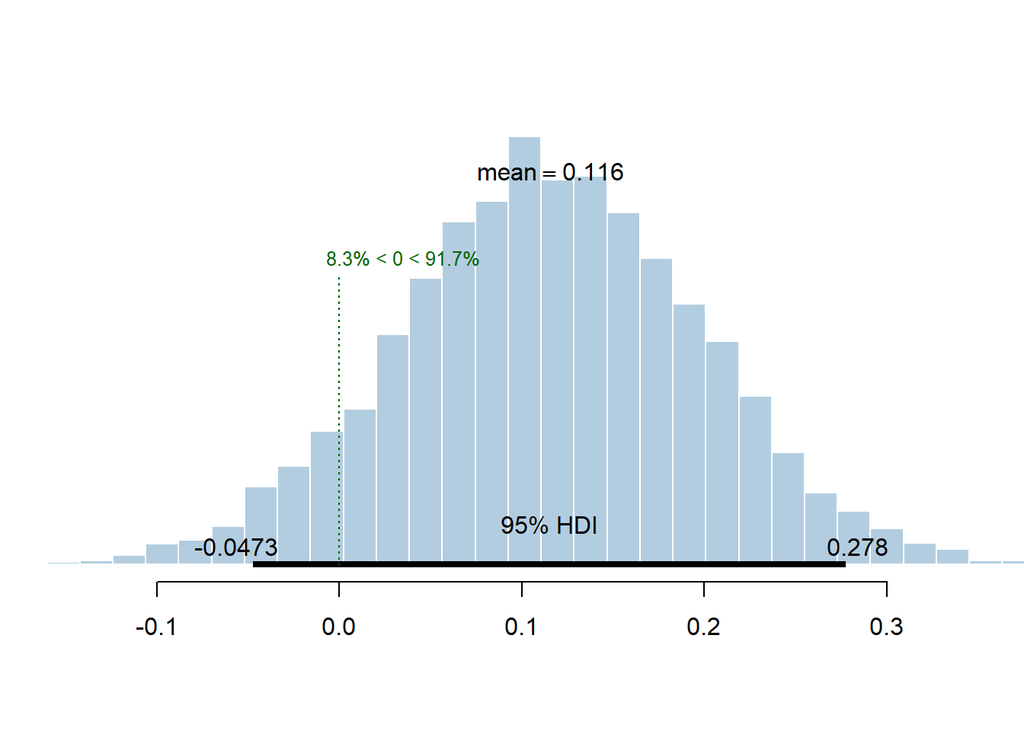

```r
Diff_Bsln1_Bsln2_High = Baseline2_High - Baseline1_High
plotPost(Diff_Bsln1_Bsln2_High, xlab = "", col = "#b3cde0", showCurve = FALSE, cex = 1, compVal = 0)
```

Check the difference between baseline1 vs. baseline2 in low reward

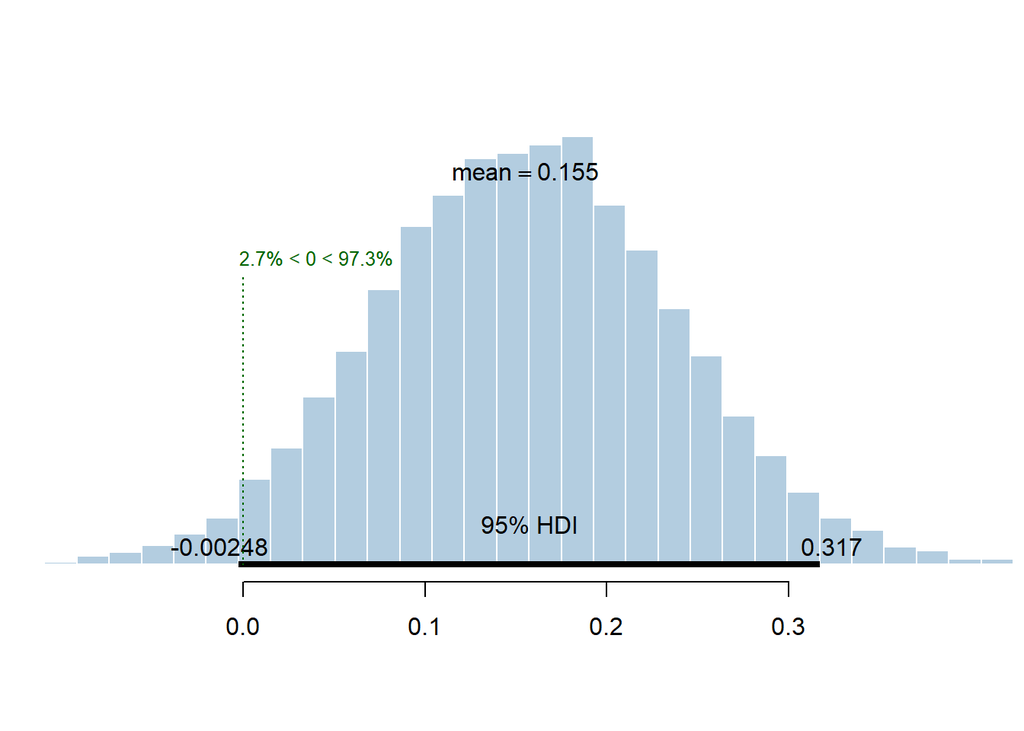

```r
Diff_Bsln1_Bsln2_Low = Baseline2_Low - Baseline1_Low
plotPost(Diff_Bsln1_Bsln2_Low, xlab = "", col = "#b3cde0", showCurve = FALSE, cex = 1, compVal = 0)
```

Check the difference between baseline2 vs. acquisition1 in high reward

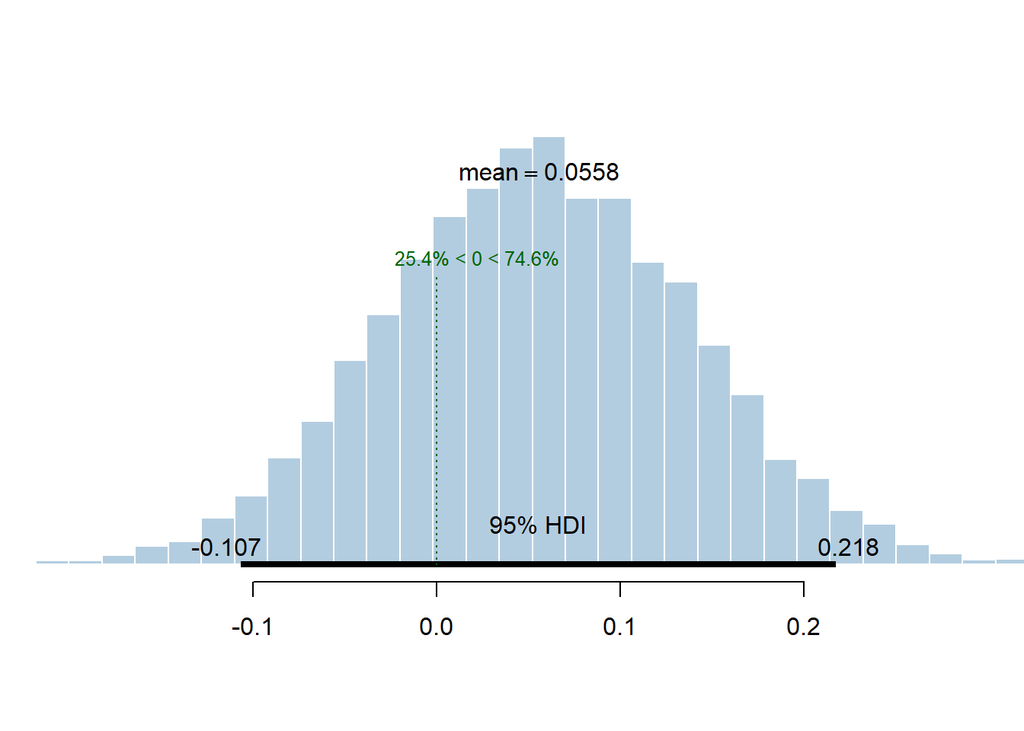

```r
Diff_Bsln2_Acq1_High = Baseline2_High - Acquisition1_High
plotPost(Diff_Bsln2_Acq1_High, xlab = "", col = "#b3cde0", showCurve = FALSE, cex = 1, compVal = 0)
```

Check the difference between baseline2 vs. acquisition1 in low reward

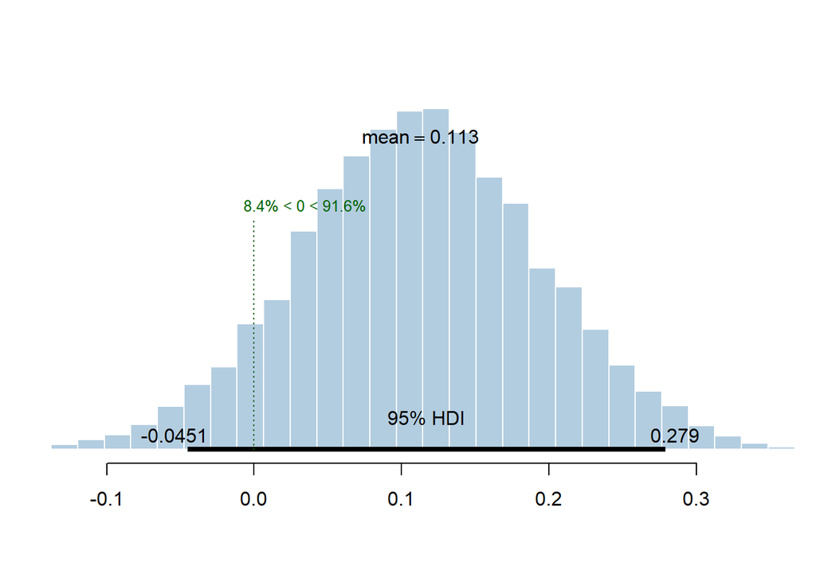

```r
Diff_Bsln2_Acq1_Low = Acquisition1_Low - Baseline2_Low
plotPost(Diff_Bsln2_Acq1_Low, xlab = "", col = "#b3cde0", showCurve = FALSE, cex = 1, compVal = 0)
```

## Reaction times

### Means - raw data

```r
summary = ddply(data.final,.(ExpPhase,Condition),plyr::summarize,Mean=c(paste(round(mean(Hits.RTs, na.rm = TRUE), digits = 2), " [", round(hdi(Hits.RTs)[[1]], digits = 2), " ", round(hdi(Hits.RTs)[[2]], digits = 2), "]")))

names(summary) = c("Reward phase", "Reward probability", "Reaction times")

# rename conditions
summary$`Reward phase` = recode(summary$`Reward phase`,
                                "Acq1" = "Acquisition1",
                                "Acq2" = "Acquisition2",
                                "Bsln1" = "Baseline1",
                                "Bsln2" = "Baseline2",
                                "Ext1" = "Extinction1",
                                "Ext2" = "Extinction2")

summary$`Reward probability` = recode(summary$`Reward probability`,
                           "High_Rew" = "High",
                           "Low_Rew" = "Low")

summary = as.data.frame(summary)

kable(summary, caption = "Reaction times per condition")
```

Reaction times per condition

| Reward phase | Reward probability | Reaction times |
| --- | --- | --- |
| Baseline1 | High | 548.84 [ 479.43 613.76 ] |
| Baseline1 | Low | 548.43 [ 458.26 610.63 ] |
| Baseline2 | High | 544.34 [ 454.56 620.36 ] |
| Baseline2 | Low | 554.01 [ 479.48 632.8 ] |
| Acquisition1 | High | 521.4 [ 437.9 587.57 ] |
| Acquisition1 | Low | 542.34 [ 463.65 593.47 ] |
| Acquisition2 | High | 528.74 [ 462 598.58 ] |
| Acquisition2 | Low | 533.94 [ 479.38 618.25 ] |
| Extinction1 | High | 528.58 [ 457.88 596.17 ] |
| Extinction1 | Low | 536.54 [ 444.89 621 ] |
| Extinction2 | High | 529.3 [ 448.24 606 ] |
| Extinction2 | Low | 543.01 [ 450.11 617.44 ] |

### Plot

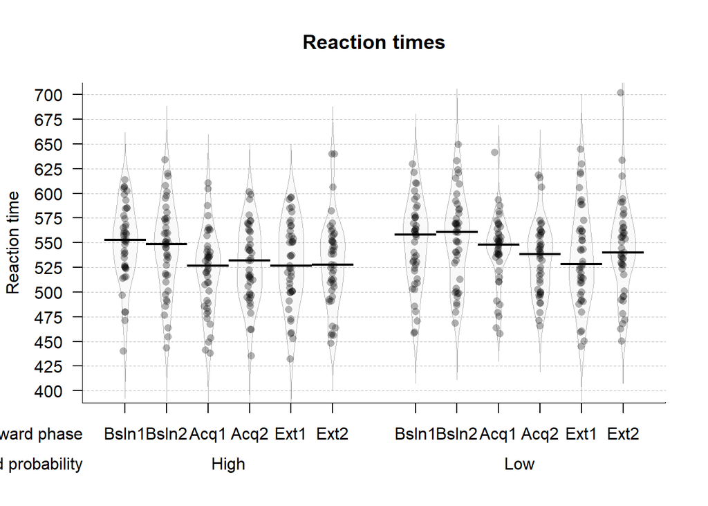

```r
# Prepare the dataset
data.plot = data.final

# rename variables
colnames(data.plot)[colnames(data.plot)=="ExpPhase"] = "Reward phase"
colnames(data.plot)[colnames(data.plot)=="Condition"] = "Reward probability"

# rename conditions
data.plot$`Reward phase` = recode(data.plot$`Reward phase`,
                                "Acq" = "Acquisition",
                                "Bsln" = "Baseline",
                                "Ext" = "Extinction")

data.plot$`Reward probability` = recode(data.plot$`Reward probability`,
                                      "High_Rew" = "High",
                                      "Low_Rew" = "Low")

# Pirate plot
  pirateplot(formula = Hits.RTs ~ `Reward phase` + `Reward probability`, # dependent~independent variables
             data=data.plot, # data frame
             main="Reaction times", # main title
             ylim=c(400,700), # y-axis: limits
             ylab="Reaction time", # y-axis: label
             theme=0, # preset theme (0: use your own)
             point.col="black", # points: color
             point.o=.3, # points: opacity (0-1)
             avg.line.fun = median,
             avg.line.col="black", # average line: color
             avg.line.lwd=2, # average line: line width
             avg.line.o=1, # average line: opacity (0-1)
             bean.b.col="black", # bean border, color
             bean.lwd=0.6, # bean border, line width
             bean.lty=1, # bean border, line type (1: solid; 2:dashed; 3: dotted; ...)
             bean.b.o=0.3, # bean border, opacity (0-1)
             bean.f.col="gray", # bean filling, color
             bean.f.o=.1, # bean filling, opacity (0-1)
             cap.beans=FALSE, # max and min values of bean densities are capped at the limits found in the data
             gl.col="gray", # gridlines: color
             gl.lty=2, # gridlines: line type (1: solid; 2:dashed; 3: dotted; ...)
             cex.lab=1, # axis labels: size
             cex.axis=1, # axis numbers: size
             cex.names = 1,
             bty="l", # plot box type
             back.col="white") # background, color
```

### Statistics

```r
# Set the working directory in order to load the models
# Set working directory
setwd(here("brms_models"))

model.full.RT.split = readRDS("model.full.RT.split.rds")
compare.waic.RT.split = readRDS("compare.RT.split.waic")
compare.RT.split.waic.weights = readRDS("compare.RT.split.waic.weights")
bR2.null.RT.split = readRDS("bR2.null.RT.split")
bR2.expphase.RT.split = readRDS("bR2.expphase.RT.split")
bR2.full.RT.split = readRDS("bR2.full.RT.split")
```

### Model comparison with WAIC

```r
print(compare.waic.RT.split)
```

```
## Output of model 'model.null.RT':
##
## Computed from 12000 by 516 log-likelihood matrix
##
##           Estimate   SE
## elpd_waic  -2538.8 24.5
## p_waic        40.4  4.6
## waic        5077.7 49.0
##
## Output of model 'model.expphase.RT':
##
## Computed from 12000 by 516 log-likelihood matrix
##
##           Estimate   SE
## elpd_waic  -2527.6 26.3
## p_waic        80.2 10.5
## waic        5055.3 52.5
##
## Output of model 'model.full.RT':
##
## Computed from 12000 by 516 log-likelihood matrix
##
##           Estimate   SE
## elpd_waic  -2426.8 24.5
## p_waic       137.6 13.2
## waic        4853.6 49.0
##
## Model comparisons:
##                   elpd_diff se_diff
## model.full.RT        0.0       0.0
## model.expphase.RT -100.8      13.0
## model.null.RT     -112.0      13.5
```

### Bayesian R squared

Null model

```r
print(bR2.null.RT.split)
```

```
##     Estimate  Est.Error      Q2.5     Q97.5
## R2 0.4599668 0.02556954 0.4063619 0.5072804
```

Experiment phase model

```r
print(bR2.expphase.RT.split)
```

```
##     Estimate Est.Error      Q2.5     Q97.5
## R2 0.5357306 0.0277915 0.4777634 0.5850535
```

Full model

```r
print(bR2.full.RT.split)
```

```
##     Estimate  Est.Error      Q2.5     Q97.5
## R2 0.7298469 0.01868379 0.6897955 0.7633356
```

### Checking the best model

Plotting the chains

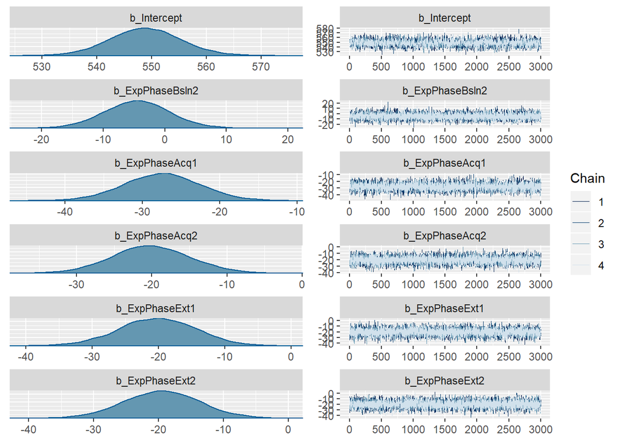

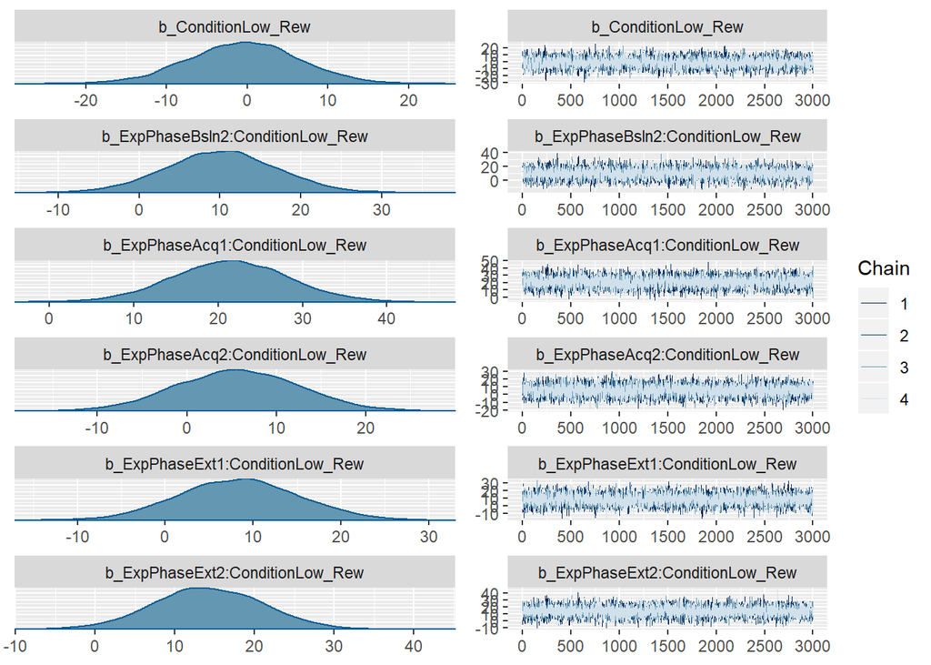

```r
# Plot chains
plot(model.full.RT.split, pars = "^b_", ask = FALSE, N=6)
```

Summary of the best model

```r
# Summary of the best model
print(tidy(model.full.RT.split, par_type = "non-varying"), digits = 1)
```

```
##                              term estimate std.error lower upper
## 1                       Intercept    548.9         6   538   560
## 2                   ExpPhaseBsln2     -4.5         5   -13     4
## 3                    ExpPhaseAcq1    -27.4         5   -36   -19
## 4                    ExpPhaseAcq2    -20.1         5   -29   -11
## 5                    ExpPhaseExt1    -20.2         6   -30   -11
## 6                    ExpPhaseExt2    -19.5         6   -29   -10
## 7                ConditionLow_Rew     -0.5         7   -12    11
## 8  ExpPhaseBsln2:ConditionLow_Rew     10.1         7    -1    21
## 9   ExpPhaseAcq1:ConditionLow_Rew     21.4         7    10    33
## 10  ExpPhaseAcq2:ConditionLow_Rew      5.7         7    -6    17
## 11  ExpPhaseExt1:ConditionLow_Rew      8.4         7    -3    20
## 12  ExpPhaseExt2:ConditionLow_Rew     14.2         7     3    25
```

### Plotting the best model

#### Sample from the posterior

```r
# Analyzing the posterior and differences between conditions

post = posterior_samples(model.full.RT.split, "^b")


################################################ Baseline 1 ####

######### High reward
Baseline1_High = post[["b_Intercept"]]
######### Low reward
Baseline1_Low = post[["b_Intercept"]] +
  post[["b_ConditionLow_Rew"]]

################################################ Baseline 2 ####

######### High reward
Baseline2_High = post[["b_Intercept"]] +
  post[["b_ExpPhaseBsln2"]]
######### Low reward
Baseline2_Low = post[["b_Intercept"]] +
  post[["b_ExpPhaseBsln2"]] +
  post[["b_ConditionLow_Rew"]] +
  post[["b_ExpPhaseBsln2:ConditionLow_Rew"]]

################################################ Acquistion 1

######### High reward
Acquisition1_High = post[["b_Intercept"]] +
  post[["b_ExpPhaseAcq1"]]
######### Low reward
Acquisition1_Low = post[["b_Intercept"]] +
  post[["b_ExpPhaseAcq1"]] +
  post[["b_ConditionLow_Rew"]] +
  post[["b_ExpPhaseAcq1:ConditionLow_Rew"]]

################################################ Acquistion 2

######### High reward
Acquisition2_High = post[["b_Intercept"]] +
  post[["b_ExpPhaseAcq2"]]
######### Low reward
Acquisition2_Low = post[["b_Intercept"]] +
  post[["b_ExpPhaseAcq2"]] +
  post[["b_ConditionLow_Rew"]] +
  post[["b_ExpPhaseAcq2:ConditionLow_Rew"]]

################################################ Extinction 1

######### High reward
Extinction1_High = post[["b_Intercept"]] +
  post[["b_ExpPhaseExt1"]]
######### Low reward
Extinction1_Low = post[["b_Intercept"]] +
  post[["b_ExpPhaseExt1"]] +
  post[["b_ConditionLow_Rew"]] +
  post[["b_ExpPhaseExt1:ConditionLow_Rew"]]

################################################ Extinction 2

######### High reward
Extinction2_High = post[["b_Intercept"]] +
  post[["b_ExpPhaseExt2"]]
######### Low reward
Extinction2_Low = post[["b_Intercept"]] +
  post[["b_ExpPhaseExt2"]] +
  post[["b_ConditionLow_Rew"]] +
  post[["b_ExpPhaseExt2:ConditionLow_Rew"]]
```

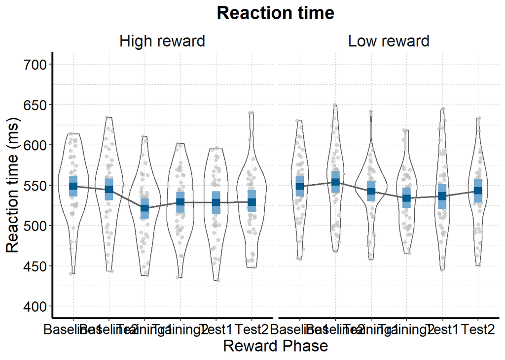

```r
# Data from the model

# make a data frame
posterior_conditions = melt(data.frame(Baseline1_High, Baseline2_High, Baseline1_Low, Baseline2_Low, Acquisition1_High, Acquisition1_Low, Acquisition2_High, Acquisition2_Low, Extinction1_High, Extinction1_Low, Extinction2_High, Extinction2_Low))

posterior_conditions =  posterior_conditions %>% separate(variable, c("Reward Phase", "Reward Probability"), "_", extra = "merge")

names(posterior_conditions)[3] = "Reaction time"

posterior_conditions$`Reward Probability` = recode(posterior_conditions$`Reward Probability`,
                                      "High" = "High reward",
                                      "Low" = "Low reward")

posterior_conditions$`Reward Phase` = recode(posterior_conditions$`Reward Phase`,
                                "Acquisition1" = "Training1",
                                "Acquisition2" = "Training2",
                                "Baseline1" = "Baseline1",
                                "Baseline1" = "Baseline2",
                                "Extinction1" = "Test1",
                                "Extinction2" = "Test2")

# Make a table with credible intervals
posterior_means = as.data.frame(c("Baseline1 High Reward",
                                  "Baseline2 High Reward",
                                  "Baseline1 Low Reward",
                                  "Baseline2 Low Reward",
                                  "Acquisition1 High Reward",
                                  "Acquisition2 High Reward",
                                  "Acquisition1 Low Reward",
                                  "Acquisition2 Low Reward",
                                  "Extinction1 High Reward",
                                  "Extinction2 High Reward",
                                  "Extinction1 Low Reward",
                                  "Extinction2 Low Reward"))
names(posterior_means)[1] = "Condition"

posterior_means$low_95_CI = c(round(hdi(Baseline1_High)[[1]], digits = 2),
                              round(hdi(Baseline2_High)[[1]], digits = 2),
                        round(hdi(Baseline1_Low)[[1]], digits = 2),
                        round(hdi(Baseline2_Low)[[1]], digits = 2),
                        round(hdi(Acquisition1_High)[[1]], digits = 2),
                        round(hdi(Acquisition2_High)[[1]], digits = 2),
                        round(hdi(Acquisition1_Low)[[1]], digits = 2),
                        round(hdi(Acquisition2_Low)[[1]], digits = 2),
                        round(hdi(Extinction1_High)[[1]], digits = 2),
                        round(hdi(Extinction2_High)[[1]], digits = 2),
                        round(hdi(Extinction1_Low)[[1]], digits = 2),
                        round(hdi(Extinction2_Low)[[1]], digits = 2))

posterior_means$high_95_CI = c(round(hdi(Baseline1_High)[[2]], digits = 2),
                              round(hdi(Baseline2_High)[[2]], digits = 2),
                        round(hdi(Baseline1_Low)[[2]], digits = 2),
                        round(hdi(Baseline2_Low)[[2]], digits = 2),
                        round(hdi(Acquisition1_High)[[2]], digits = 2),
                        round(hdi(Acquisition2_High)[[2]], digits = 2),
                        round(hdi(Acquisition1_Low)[[2]], digits = 2),
                        round(hdi(Acquisition2_Low)[[2]], digits = 2),
                        round(hdi(Extinction1_High)[[2]], digits = 2),
                        round(hdi(Extinction2_High)[[2]], digits = 2),
                        round(hdi(Extinction1_Low)[[2]], digits = 2),
                        round(hdi(Extinction2_Low)[[2]], digits = 2))

posterior_means$low_50_CI = c(round(hdi(Baseline1_High,0.5)[[1]], digits = 2),
                              round(hdi(Baseline2_High,0.5)[[1]], digits = 2),
                        round(hdi(Baseline1_Low,0.5)[[1]], digits = 2),
                        round(hdi(Baseline2_Low,0.5)[[1]], digits = 2),
                        round(hdi(Acquisition1_High,0.5)[[1]], digits = 2),
                        round(hdi(Acquisition2_High,0.5)[[1]], digits = 2),
                        round(hdi(Acquisition1_Low,0.5)[[1]], digits = 2),
                        round(hdi(Acquisition2_Low,0.5)[[1]], digits = 2),
                        round(hdi(Extinction1_High,0.5)[[1]], digits = 2),
                        round(hdi(Extinction2_High,0.5)[[1]], digits = 2),
                        round(hdi(Extinction1_Low,0.5)[[1]], digits = 2),
                        round(hdi(Extinction2_Low,0.5)[[1]], digits = 2))

posterior_means$high_50_CI = c(round(hdi(Baseline1_High,0.5)[[2]], digits = 2),
                              round(hdi(Baseline2_High,0.5)[[2]], digits = 2),
                        round(hdi(Baseline1_Low,0.5)[[2]], digits = 2),
                        round(hdi(Baseline2_Low,0.5)[[2]], digits = 2),
                        round(hdi(Acquisition1_High,0.5)[[2]], digits = 2),
                        round(hdi(Acquisition2_High,0.5)[[2]], digits = 2),
                        round(hdi(Acquisition1_Low,0.5)[[2]], digits = 2),
                        round(hdi(Acquisition2_Low,0.5)[[2]], digits = 2),
                        round(hdi(Extinction1_High,0.5)[[2]], digits = 2),
                        round(hdi(Extinction2_High,0.5)[[2]], digits = 2),
                        round(hdi(Extinction1_Low,0.5)[[2]], digits = 2),
                        round(hdi(Extinction2_Low,0.5)[[2]], digits = 2))


posterior_means =  posterior_means %>% separate(Condition, c("Reward Phase", "Reward Probability"), " ", extra = "merge")

posterior_means$`Reward Probability` = recode(posterior_means$`Reward Probability`,
                                      "High Reward" = "High reward",
                                      "Low Reward" = "Low reward")

posterior_means$`Reward Phase` = recode(posterior_means$`Reward Phase`,
                                "Acquisition1" = "Training1",
                                "Acquisition2" = "Training2",
                                "Baseline1" = "Baseline1",
                                "Baseline1" = "Baseline2",
                                "Extinction1" = "Test1",
                                "Extinction2" = "Test2")

# Create this variable in order to have it for plotting (this is a quick hack: in plotting the CIs this variable is added and then subtracted)
posterior_means$`Reaction time` = c(555,555,555,555,555,555)


# Raw data
# Prepare the dataset
data.plot = data.final

# rename variables
colnames(data.plot)[colnames(data.plot)=="ExpPhase"] = "Reward Phase"
colnames(data.plot)[colnames(data.plot)=="Condition"] = "Reward Probability"

# rename conditions
data.plot$`Reward Phase` = recode(data.plot$`Reward Phase`,
                                "Acq1" = "Training1",
                                "Acq2" = "Training2",
                                "Bsln1" = "Baseline1",
                                "Bsln2" = "Baseline2",
                                "Ext1" = "Test1",
                                "Ext2" = "Test2")

data.plot$`Reward Probability` = recode(data.plot$`Reward Probability`,
                                      "High_Rew" = "High reward",
                                      "Low_Rew" = "Low reward")

data.plot$`Reaction time` = data.plot$Hits.RTs


# Violin + the model
# tiff("RTs_split.tiff", units="in", width=16, height=5, res=800)

f.sup.b = ggplot(data=data.plot, aes(x=`Reward Phase`, y=`Reaction time`, label=`Reward Probability`)) +
  # violin of the raw data
  geom_violin(data=data.plot, color ="#636363",trim = TRUE,alpha="0.2") +
  # individual participants for the raw data
  # geom_point(binaxis='y', stackdir='center', dotsize=0.5, alpha="0.2") +
  geom_jitter(dotsize=0.9, alpha="0.6",width = 0.1,color="#bdbdbd")+
  # mean of the model
  stat_summary(data = posterior_conditions, aes(x=`Reward Phase`, y=`Reaction time`, group=`Reward Probability`),fun.y = mean, geom="line",size=0.8, colour = "#636363")+
  # 95 credible intervals of the model
  geom_linerange(data = posterior_means,width=.1, aes(ymin=`Reaction time`-`Reaction time`+low_95_CI, ymax=`Reaction time`-`Reaction time`+high_95_CI), size = 4, color = "#74a9cf", alpha = 1) +
  # 50 credible intervals of the model
  geom_linerange(data = posterior_means,width=.1, aes(ymin=`Reaction time`-`Reaction time`+low_50_CI, ymax=`Reaction time`-`Reaction time`+high_50_CI), size = 4, color = "#045a8d", alpha = 1) +
  scale_x_discrete(limits=c("Baseline1","Baseline2", "Training1","Training2", "Test1","Test2")) +
  facet_grid(.~`Reward Probability`) +
  scale_y_continuous(limits =c(400,700),breaks=seq(400,700,50)) +
  labs(title="Reaction time", y = "Reaction time (ms)") +
  theme(
    axis.line = element_line(size=1, colour = "black"),
    panel.grid.major = element_line(colour = "grey",size = 0.1,linetype = "dashed"),
    panel.grid.minor = element_line(colour = "grey",size = 0.1,linetype = "dashed"),
    panel.border = element_blank(),
    panel.background = element_blank(),
    plot.title = element_text(size = 18,  face = "bold",hjust = 0.5),
    text=element_text(colour="black", size = 14),
    axis.text.x=element_text(colour="black", size = 14),
    axis.text.y=element_text(colour="black", size = 14),
    axis.title=element_text(size=16,colour = "black")) +
  theme(strip.background =element_rect(fill="white")) +
  theme(strip.text = element_text(size = 16))

# dev.off()

f.sup.b
```

Table of means across conditions

```r
# Make a table with conditions
posterior_means = as.data.frame(c("Baseline1 High Reward",
                                  "Baseline1 Low Reward",
                                  "Baseline2 High Reward",
                                  "Baseline2 Low Reward",
                                  "Acquisition1 High Reward",
                                  "Acquisition1 Low Reward",
                                  "Acquisition2 High Reward",
                                  "Acquisition2 Low Reward",
                                  "Extinction1 High Reward",
                                  "Extinction1 Low Reward",
                                  "Extinction2 High Reward",
                                  "Extinction2 Low Reward"))

names(posterior_means)[1] = "Condition"

posterior_means$Mean = c(paste(round(mean(Baseline1_High), digits = 2), " [", round(hdi(Baseline1_High)[[1]], digits = 2), " ", round(hdi(Baseline1_High)[[2]], digits = 2), "]"),
                         paste(round(mean(Baseline1_Low), digits = 2), " [", round(hdi(Baseline1_Low)[[1]], digits = 2), " ", round(hdi(Baseline1_Low)[[2]], digits = 2), "]"),
                         paste(round(mean(Baseline2_High), digits = 2), " [", round(hdi(Baseline2_High)[[1]], digits = 2), " ", round(hdi(Baseline2_High)[[2]], digits = 2), "]"),
                         paste(round(mean(Baseline2_Low), digits = 2), " [", round(hdi(Baseline2_Low)[[1]], digits = 2), " ", round(hdi(Baseline2_Low)[[2]], digits = 2), "]"),
                         paste(round(mean(Acquisition1_High), digits = 2), " [", round(hdi(Acquisition1_High)[[1]], digits = 2), " ", round(hdi(Acquisition1_High)[[2]], digits = 2), "]"),
                         paste(round(mean(Acquisition1_Low), digits = 2), " [", round(hdi(Acquisition1_Low)[[1]], digits = 2), " ", round(hdi(Acquisition1_Low)[[2]], digits = 2), "]"),
                         paste(round(mean(Acquisition2_High), digits = 2), " [", round(hdi(Acquisition2_High)[[1]], digits = 2), " ", round(hdi(Acquisition2_High)[[2]], digits = 2), "]"),
                         paste(round(mean(Acquisition2_Low), digits = 2), " [", round(hdi(Acquisition2_Low)[[1]], digits = 2), " ", round(hdi(Acquisition2_Low)[[2]], digits = 2), "]"),
                         paste(round(mean(Extinction1_High), digits = 2), " [", round(hdi(Extinction1_High)[[1]], digits = 2), " ", round(hdi(Extinction1_High)[[2]], digits = 2), "]"),
                         paste(round(mean(Extinction1_Low), digits = 2), " [", round(hdi(Extinction1_Low)[[1]], digits = 2), " ", round(hdi(Extinction1_Low)[[2]], digits = 2), "]"),
                         paste(round(mean(Extinction2_High), digits = 2), " [", round(hdi(Extinction2_High)[[1]], digits = 2), " ", round(hdi(Extinction2_High)[[2]], digits = 2), "]"),
                         paste(round(mean(Extinction2_Low), digits = 2), " [", round(hdi(Extinction2_Low)[[1]], digits = 2), " ", round(hdi(Extinction2_Low)[[2]], digits = 2), "]"))

names(posterior_means)[2] = "Mean [HDI]"

posterior_means =  posterior_means %>% separate(Condition, c("Reward Phase", "Reward Probability"), " ", extra = "merge")

kable(posterior_means, caption = "Means per condition")
```

Means per condition

| Reward Phase | Reward Probability | Mean [HDI] |
| --- | --- | --- |
| Baseline1 | High Reward | 548.86 [ 535.97 561.35 ] |
| Baseline1 | Low Reward | 548.38 [ 535.83 560.97 ] |
| Baseline2 | High Reward | 544.34 [ 531.22 558.49 ] |
| Baseline2 | Low Reward | 553.98 [ 540.67 567.69 ] |
| Acquisition1 | High Reward | 521.42 [ 508.48 533.66 ] |
| Acquisition1 | Low Reward | 542.35 [ 530.05 555.45 ] |
| Acquisition2 | High Reward | 528.74 [ 515.92 541.36 ] |
| Acquisition2 | Low Reward | 533.91 [ 521.41 547.24 ] |
| Extinction1 | High Reward | 528.64 [ 514.39 542.24 ] |
| Extinction1 | Low Reward | 536.51 [ 520.49 551.37 ] |
| Extinction2 | High Reward | 529.32 [ 516.53 543.7 ] |
| Extinction2 | Low Reward | 543.01 [ 528.56 557.28 ] |

### Inference about the best model

Check the difference between baseline1 vs. baseline2 in high reward

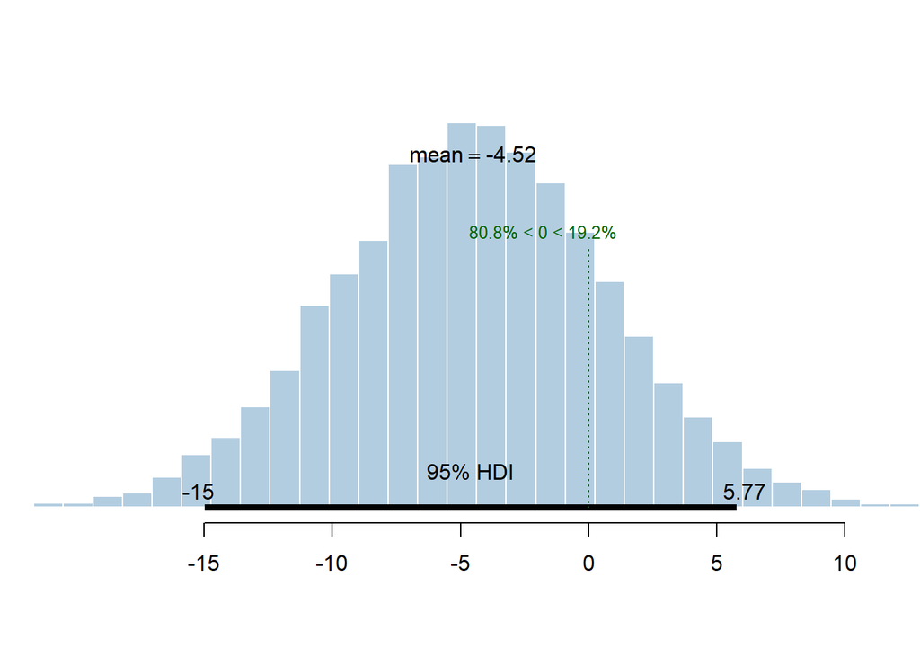

```r
Diff_Bsln1_Bsln2_High = Baseline2_High - Baseline1_High
plotPost(Diff_Bsln1_Bsln2_High, xlab = "", col = "#b3cde0", showCurve = FALSE, cex = 1, compVal = 0)
```

Check the difference between baseline1 vs. baseline2 in low reward

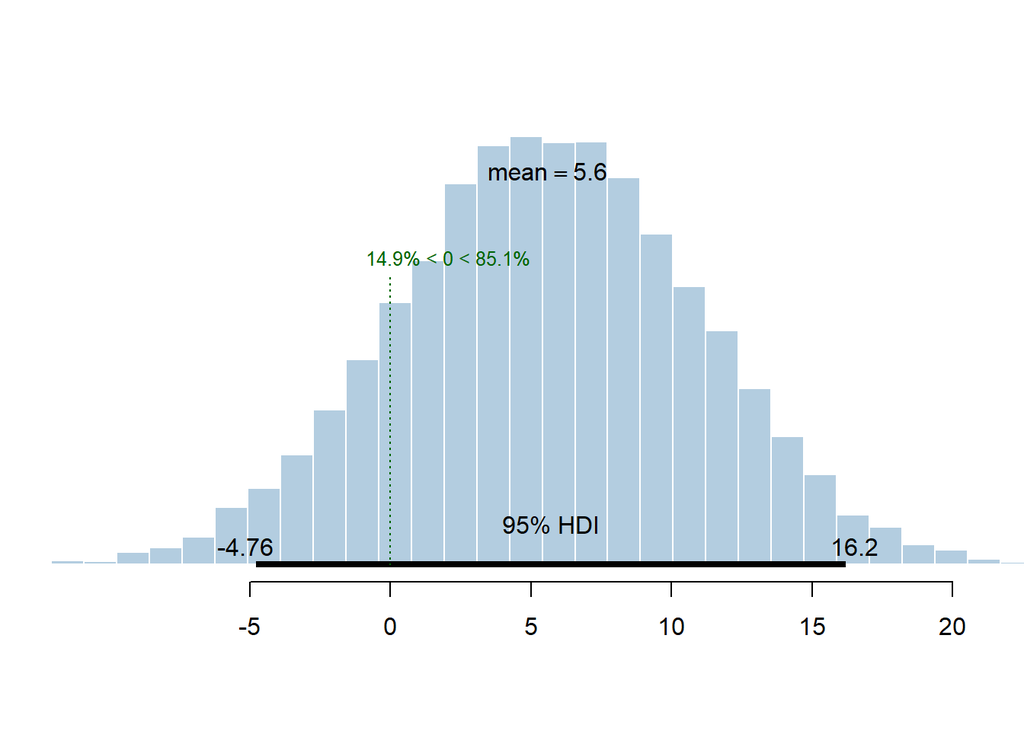

```r
Diff_Bsln1_Bsln2_Low = Baseline2_Low - Baseline1_Low
plotPost(Diff_Bsln1_Bsln2_Low, xlab = "", col = "#b3cde0", showCurve = FALSE, cex = 1, compVal = 0)
```

Check the difference between baseline2 vs. acquisition1 in high reward

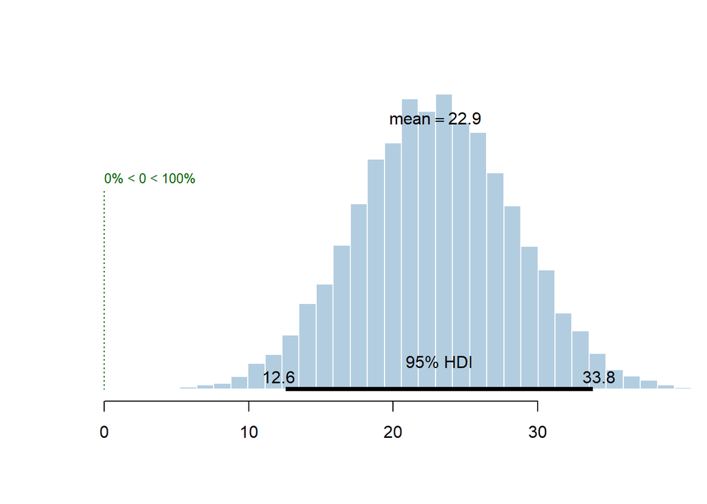

```r
Diff_Bsln2_Acq1_High = Baseline2_High - Acquisition1_High
plotPost(Diff_Bsln2_Acq1_High, xlab = "", col = "#b3cde0", showCurve = FALSE, cex = 1, compVal = 0)
```

Check the difference between baseline2 vs. acquisition1 in low reward

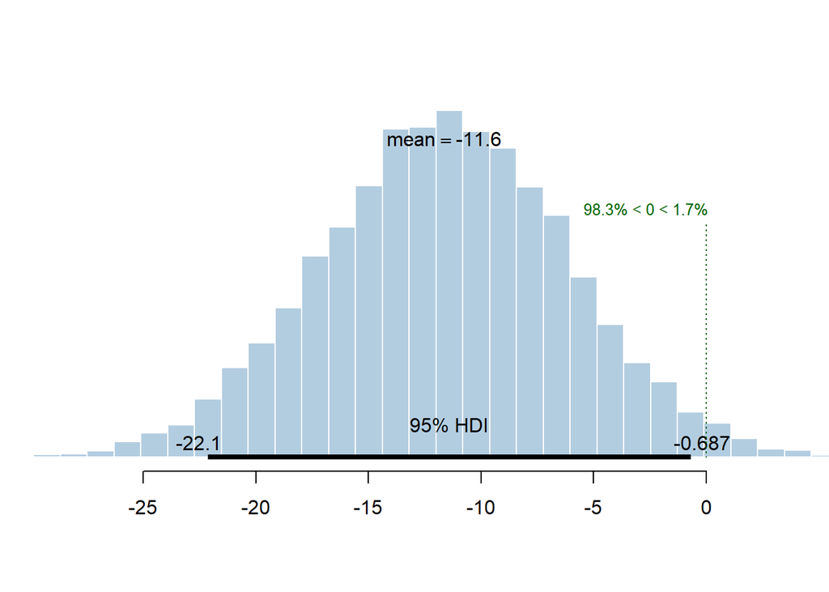

```r
Diff_Bsln2_Acq1_Low = Acquisition1_Low - Baseline2_Low
plotPost(Diff_Bsln2_Acq1_Low, xlab = "", col = "#b3cde0", showCurve = FALSE, cex = 1, compVal = 0)
```

# Creating figures for the manuscript

```r
library(cowplot)
# Figure 2
# tiff("C:/Users/igrahek/Documents/Studies/SSVEP Reward - Soren & Antonio/Experiment 1/SSVEP_reward/figures/Figure2.tiff", units="in", width=15, height=10, res=300)
#
# ggdraw() +
#     draw_plot(f.2.a, x = 0.03, y = 0.5, width = .45, height = .45) +
#     draw_plot(f.2.b, x = 0.53, y = .5, width = .45, height = .45) +
#     draw_plot(f.2.c, x = 0.03, y = 0, width = 0.45, height = 0.45) +
#     draw_plot(f.2.d, x = 0.53, y = 0, width = 0.45, height = 0.45) +
#
#   draw_plot_label(label = c("A", "B", "C","D"), size = 20,
#                   x = c(0, 0.5, 0,0.5), y = c(1, 1, 0.5,0.5))
#
# dev.off()
#
# # Figure 1 Supplementary materials
# tiff("C:/Users/igrahek/Documents/Studies/SSVEP Reward - Soren & Antonio/Experiment 1/SSVEP_reward/figures/FigureSup1.tiff", units="in", width=15, height=10, res=300)
#
# ggdraw() +
#     draw_plot(f.sup.a, x = 0.03, y = 0.5, width = .9, height = .45) +
#     draw_plot(f.sup.b, x = 0.03, y = 0, width = .9, height = .45) +
#
#   draw_plot_label(label = c("A", "B"), size = 20,
#                   x = c(0, 0), y = c(1,0.5))
#
# dev.off()
```